# Group 4 Assignment 3

## (Q1) k-Nearest Neighbors

> [Using] the Penguin dataset . . . please use [the] K-nearest neighbors algorithm to predict the species variable.

The **KNN Algorithm** is a simple classification algorithm. It stores the training data and classifies new cases by a majority vote of the case’s k-nearest neighbors.

The algorithm is sensitive to the units of the chosen predictor variables. It is important that we transform all the values to a common scale. A frequently used practice is to normalize the data to the interval [0, 1].

KNN works well when all predictor data has been converted to numerics with the exception of the target variable `species`.

*A note on data preparation:* this is the third time we’ve worked with the `palmerpenguins` data. We’ve repeated some data preparation and EDA in the appendix. The data prep we do here are items **specific to the k-NN algorithm**.

```r
penguins_na_omit <- readr::read_rds('data/penguins_na_omit.Rds')

normalize <- function(x) {
  (x - min(x)) / (max(x) - min(x))
}

penguins_df_norm <- penguins_na_omit %>%
  select(-year) %>%
  mutate_if(is.factor, as.integer) %>%
  mutate_if(is.numeric, normalize) %>%
  mutate(species = penguins_na_omit$species)
```

### Create Training and Test sets

The first is used to train the system, while the second is used to evaluate the learned or trained system. In practice, the division of your data set into a test and a training sets is disjoint: the most common splitting choice is to take 2/3 of your original data set as the training set, while the 1/3 that remains will compose the test set.

```r
# Create sample data for testing and training.
set.seed(1234)
ind <- sample(2, nrow(penguins_df_norm), replace=TRUE, prob=c(0.67, 0.33))

# Training and test sets
penguin.train <- penguins_df_norm %>% filter(ind == 1) %>% select(-species)
penguin.test  <- penguins_df_norm %>% filter(ind == 2) %>% select(-species)

# Training and test labels
penguin.trainLabels <- penguins_df_norm$species[ind == 1]
penguin.testLabels <- penguins_df_norm$species[ind == 2]
```

### Build KNN Classifier

This step performs the actual classification. Note: the k parameter is often an odd number to avoid ties in the voting scores. A good starting point for k is the square root of the total number of observations.

```r
penguin_pred <- knn(
  k = 19,
  train = penguin.train,
  test = penguin.test,
  cl = penguin.trainLabels)

caret::confusionMatrix(
  penguin_pred,
  penguin.testLabels)
```

```
## Confusion Matrix and Statistics
##
##            Reference
## Prediction  Adelie Chinstrap Gentoo
##   Adelie        38         0      0
##   Chinstrap      0        25      0
##   Gentoo         0         0     37
##
## Overall Statistics
##
##                Accuracy : 1
##                  95% CI : (0.9638, 1)
##     No Information Rate : 0.38
##     P-Value [Acc > NIR] : < 2.2e-16
##
##                   Kappa : 1
##
##  Mcnemar's Test P-Value : NA
##
## Statistics by Class:
##
##                      Class: Adelie Class: Chinstrap Class: Gentoo
## Sensitivity                   1.00             1.00          1.00
## Specificity                   1.00             1.00          1.00
## Pos Pred Value                1.00             1.00          1.00
## Neg Pred Value                1.00             1.00          1.00
## Prevalence                    0.38             0.25          0.37
## Detection Rate                0.38             0.25          0.37
## Detection Prevalence          0.38             0.25          0.37
## Balanced Accuracy             1.00             1.00          1.00
```

With k = 19 we have zero misclassifications!

What are the accuracy measures for other values of k?

```r
k_search <- function(k) {
  penguin_pred <- knn(
    k = k,
    train = penguin.train,
    test = penguin.test,
    cl = penguin.trainLabels)

  cm <- caret::confusionMatrix(
    penguin_pred,
    penguin.testLabels)

  data.frame(
    k = k,
    Adelie = cm$byClass[1, 11],
    Chinstrap = cm$byClass[2, 11],
    Gentoo = cm$byClass[3, 11] )
}

res <- NULL
for (i in seq(1, 21, 2)) {
  res_i <- k_search(i)
  if (is.null(res))
    res <- res_i
  else
    res <- rbind(res, res_i)
}

print(res)
```

```
##     k    Adelie Chinstrap Gentoo
## 1   1 0.9919355 0.9800000      1
## 2   3 0.9868421 0.9933333      1
## 3   5 0.9919355 0.9800000      1
## 4   7 0.9919355 0.9800000      1
## 5   9 0.9919355 0.9800000      1
## 6  11 0.9919355 0.9800000      1
## 7  13 0.9919355 0.9800000      1
## 8  15 0.9919355 0.9800000      1
## 9  17 1.0000000 1.0000000      1
## 10 19 1.0000000 1.0000000      1
## 11 21 1.0000000 1.0000000      1
```

We see that k = 17 is the first value of k for which we have perfect accuracy. But, the accuracy is extremely good for all values of k.

### What if we do not know `island`?

From previous homework assignments, we found that `island` was an extremely helpful variable because not all species are found on each island. If we wanted to build a model without `island` (for individuals we might find at sea, for example), how well would it perform?

```r
cols <- c(
  "bill_length_mm", "bill_depth_mm",
  "flipper_length_mm", "body_mass_g", "sex")

k_search <- function(k) {
  penguin_pred <- knn(
    k = k,
    train = penguin.train[, cols],
    test = penguin.test[, cols],
    cl = penguin.trainLabels)

  cm <- caret::confusionMatrix(
    penguin_pred,
    penguin.testLabels)

  data.frame(
    k = k,
    Adelie = cm$byClass[1, 11],
    Chinstrap = cm$byClass[2, 11],
    Gentoo = cm$byClass[3, 11] )
}

res <- NULL
for (i in seq(1, 21, 2)) {
  res_i <- k_search(i)
  if (is.null(res))
    res <- res_i
  else
    res <- rbind(res, res_i)
}

print(res)
```

```
##     k    Adelie Chinstrap Gentoo
## 1   1 0.9707131 0.9533333      1
## 2   3 0.9919355 0.9800000      1
## 3   5 0.9838710 0.9600000      1
## 4   7 0.9838710 0.9600000      1
## 5   9 0.9838710 0.9600000      1
## 6  11 0.9838710 0.9600000      1
## 7  13 0.9838710 0.9600000      1
## 8  15 0.9838710 0.9600000      1
## 9  17 0.9838710 0.9600000      1
## 10 19 0.9838710 0.9600000      1
## 11 21 0.9838710 0.9600000      1
```

With k as low as 3 we get a pretty good model without using `island`. However, we do not see perfect classification as we do when the variable is included.

## Loan Data Exploration and Prep

### Data Exploration

```r
# Load raw CSV file
loans_raw <- readr::read_csv("data/Loan_approval.csv")
```

Before conducting any modeling, we will explore our dataset. Below describes the `Loan_approval` dataset where we have 614 observations with 13 features used to describe these observations. eight of these variables are factors while the other five are numeric.

```r
summary(loans_raw) %>% kable() %>%
  kable_styling(
      full_width = FALSE, position = "center", bootstrap_options = c("hover")) %>%
  scroll_box() %>%
  kable_classic_2()
```

|  | Loan_ID | Gender | Married | Dependents | Education | Self_Employed | ApplicantIncome | CoapplicantIncome | LoanAmount | Loan_Amount_Term | Credit_History | Property_Area | Loan_Status |
| --- | --- | --- | --- | --- | --- | --- | --- | --- | --- | --- | --- | --- | --- |
|  | Length:614 | Length:614 | Length:614 | Length:614 | Length:614 | Length:614 | Min. : 150 | Min. : 0 | Min. : 9.0 | Min. : 12 | Min. :0.0000 | Length:614 | Length:614 |
|  | Class :character | Class :character | Class :character | Class :character | Class :character | Class :character | 1st Qu.: 2878 | 1st Qu.: 0 | 1st Qu.:100.0 | 1st Qu.:360 | 1st Qu.:1.0000 | Class :character | Class :character |
|  | Mode :character | Mode :character | Mode :character | Mode :character | Mode :character | Mode :character | Median : 3812 | Median : 1188 | Median :128.0 | Median :360 | Median :1.0000 | Mode :character | Mode :character |
|  | NA | NA | NA | NA | NA | NA | Mean : 5403 | Mean : 1621 | Mean :146.4 | Mean :342 | Mean :0.8422 | NA | NA |
|  | NA | NA | NA | NA | NA | NA | 3rd Qu.: 5795 | 3rd Qu.: 2297 | 3rd Qu.:168.0 | 3rd Qu.:360 | 3rd Qu.:1.0000 | NA | NA |
|  | NA | NA | NA | NA | NA | NA | Max. :81000 | Max. :41667 | Max. :700.0 | Max. :480 | Max. :1.0000 | NA | NA |
|  | NA | NA | NA | NA | NA | NA | NA | NA | NA’s :22 | NA’s :14 | NA’s :50 | NA | NA |

We can visualize the amount of missing data that is observed in our dataset with the `vis_miss` function from the `naniar` package. Majority of the data is complete and approximate 1.9% of the dataset is missing. There are no observations with majority of features missing, and there are no features that are abnormally sparse. A threshold of 0.5 was set for observation completion, meaning if 50% of the features measure NA for any observation, that row is removed from our dataset. For this case, no rows in the dataset triggered this threshold. The few pieces of missing information will need to be handled with imputation, removal. Of the categorical variables, this includes, `Gender`, `Married`, `Dependents`, `Self_Employed` and `Credit_History`. of the numeric variables this includes `Loan Amount`, `Loan_Amount_Terms`, and `Credit_History`. Imputation methods explored include, mean, mode, bagimpute, knn, and median.

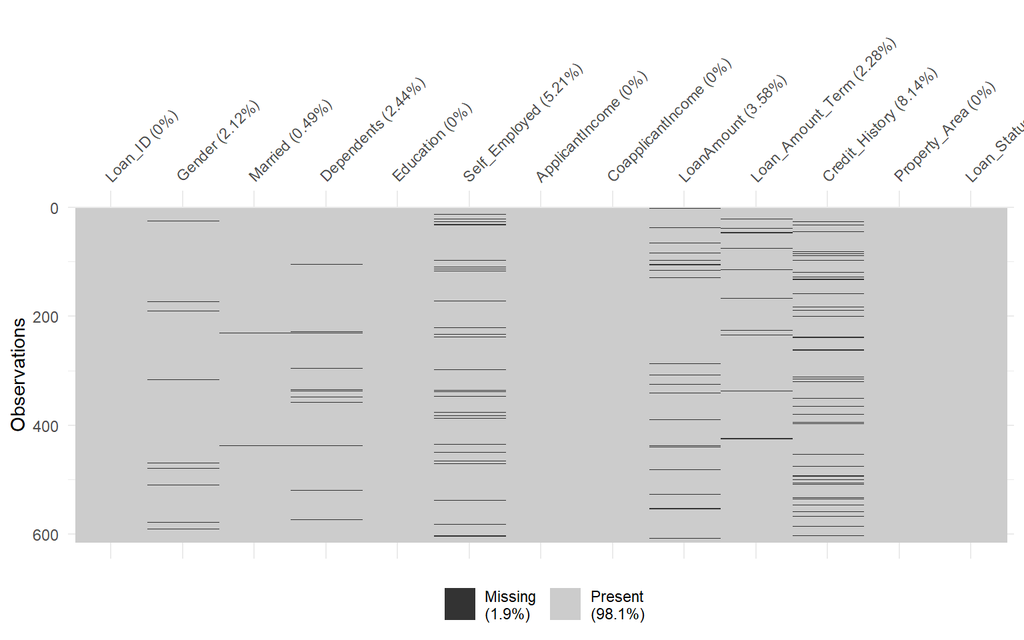

```r
naniar::vis_miss(loans_raw)
```

```r
# # Sample code for testing the "50% missing threshold"
# limitmissing <- .5*ncol(loans_raw)
# retain <- apply(loans_raw, MARGIN= 1, function(y) sum(length(which(is.na(y)))))<limitmissing
# Dataset <- loans_raw[retain,]
```

Simple barplot is showing the frequency of all categorical variables in the dataset, as well as a histogram to show distribution of numeric features in the dataset. `Gender` comprised primarily of `Male` and this is a feature that is decidely removed from our dataset to avoid making loan approval predictions based on any gender biases. on the `Loan_Amount_Term`, most individuals go with the 30 year mortgage, while few select terms below or above that. Many of the distributions skew right, however no transformations to normalize this dataset are necessary for decision tree classification-based models.

```r
unique(loans_raw$Loan_Amount_Term)
```

```
##  [1] 360 120 240  NA 180  60 300 480  36  84  12
```

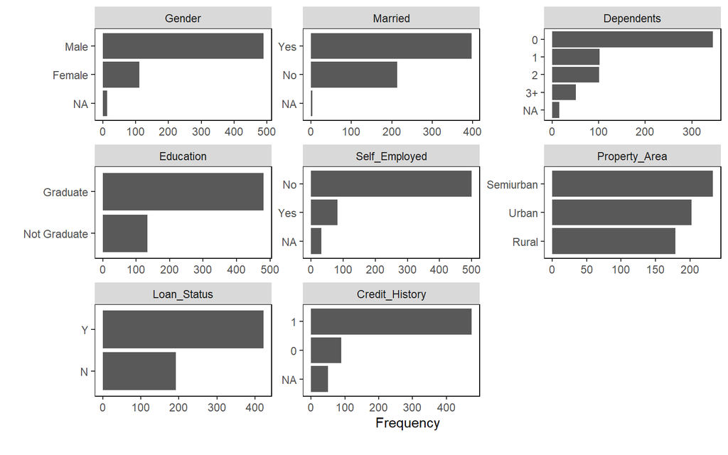

```r
plot_bar(loans_raw, theme_config = defaulttheme, ncol = 3)
```

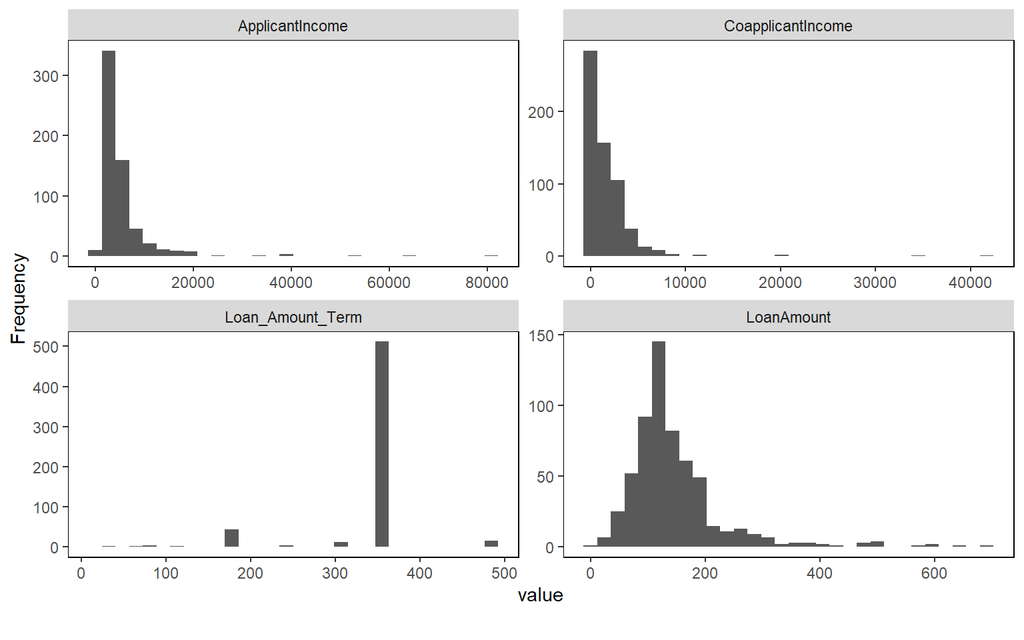

```r
plot_histogram(loans_raw,theme_config = defaulttheme, ncol = 2)
```

The bar chart also depicts that there is class imbalance of the our response variable `Loan_Status`. Knowing this, we may need to perform some over/undersampling techniques in order to obtain better training sets. The table below shows this as 69% approved `Y` and 31% denied `N`. With this, we know that at the very least, guessing the majority class will provide a 69% accuracy and our models need to surpass this. Kappa is a metric used to measure accuracy that is normalized based on the class distribution and will be used to compare model performance. For Kappa, values of 0-0.20 as slight, 0.21-0.40 as fair, 0.41-0.60 as moderate, 0.61-0.80 as substantial, and 0.81-1 as almost perfect.

```r
prop.table(table(loans_raw$Loan_Status)) %>% as.data.frame() %>%
  mutate(Freq=percent(Freq)) %>%
  rename("Class" = Var1, "Proportion" = "Freq") %>%
  mutate(Count =table(loans_raw$Loan_Status)) %>% kable() %>%
  kable_styling(
      full_width = FALSE, position = "center", bootstrap_options = c("hover")) %>%
  kable_classic_2()
```

| Class | Proportion | Count |
| --- | --- | --- |
| N | 31% | 192 |
| Y | 69% | 422 |

Next we look at the same categorical and numeric distributions, however we separate these by our predictor variable to assess any interesting or unusual patterns. We notice that the proportion of Y/N are distributed in our categorical variables such that there is no feature that determines our prediction (which would provide less incentive to build models). However, `Credit_Score` seems to be a major determining factor.

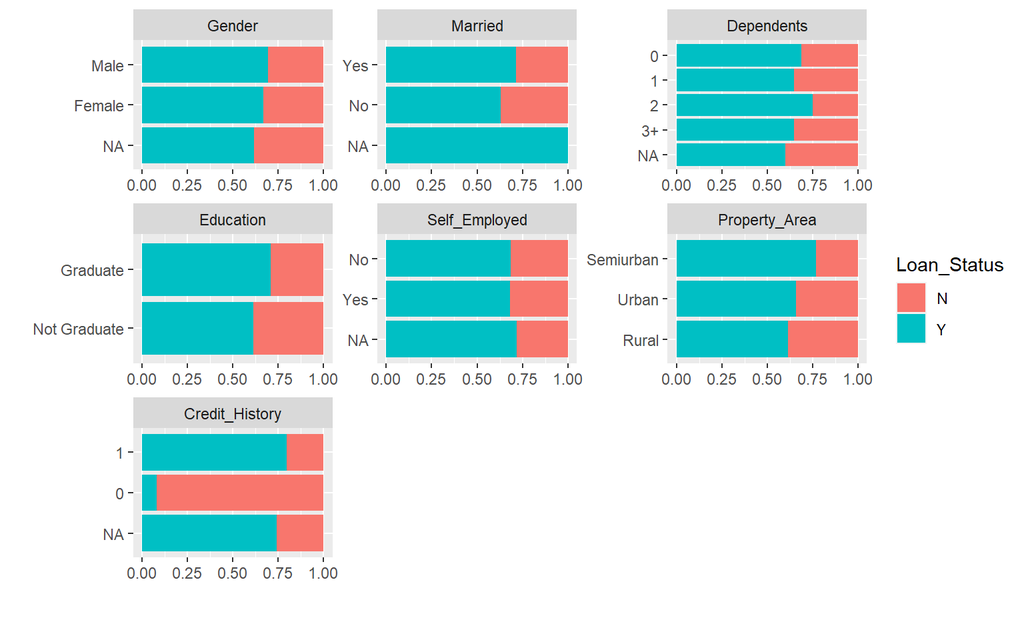

```r
plot_bar(loans_raw, by = "Loan_Status")
```

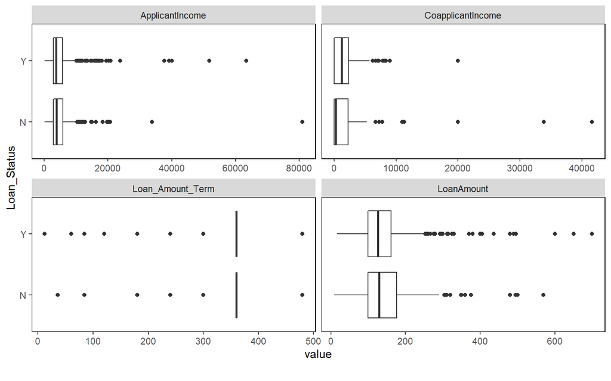

```r
plot_boxplot(loans_raw, by = "Loan_Status", theme_config = defaulttheme, ncol = 2)
```

Tree-based models are not susceptible to the negative impacts of colinearity, however we can still check for if there is any capacity for feature reduction by looking at our pairwise comparison of numeric features. if there are features that describe the data too similarly, they may not provide much additional benefit in the model. For this particular dataset, we do not observe heavy multicolinearity.

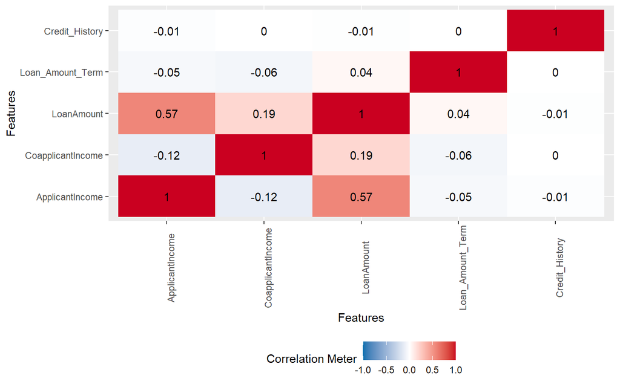

```r
plot_correlation(
  loans_raw,
  type = c("continuous"),
  cor_args = list(use = "pairwise.complete.obs"))
```

### Data preparation

While working through questions 2-5 we experimented with various data preparation and cleaning options. We’ve consolidated our selected steps here to make it convenient for the reader to follow along.

We imputed missing values using the mode or the mean, depending on the variable. We also added two new variables: `Total_Income` and `IncomeLoanRatio`.

```r
# Helper functions
mode <- function(x, ...) {
  tx <- table(x)
  which(tx == max(tx)) %>% sort %>% `[`(., 1) %>% names
}
impute <- function(x, fun) {
  fval <- fun(x, na.rm = TRUE)
  y <- ifelse(is.na(x), fval, x)
  return(y)
}

# Prep statements
loans <- loans_raw %>%
  select(-Loan_ID, -Gender) %>%
  mutate(
    Married            = impute(Married, mode),
    Dependents         = impute(Dependents, mode),
    Education          = impute(Education, mode),
    Self_Employed      = impute(Self_Employed, mode),
    ApplicantIncome    = impute(ApplicantIncome, mean),
    CoapplicantIncome  = impute(CoapplicantIncome, mean),
    LoanAmount         = impute(LoanAmount, mean),
    Loan_Amount_Term   = impute(Loan_Amount_Term, mean),
    Credit_History     = impute(Credit_History, mode),
    Property_Area      = impute(Property_Area, mode),
    Loan_Status        = impute(Loan_Status, mode)  ) %>%
  mutate(
    Total_Income = ApplicantIncome + CoapplicantIncome) %>%
  select(-ApplicantIncome, -CoapplicantIncome) %>%
  mutate(IncomeLoanRatio = Total_Income / LoanAmount) %>%
  mutate_if(is.character, factor)

# Create dummyVars, *including* base levels!
dv <- dummyVars(~ ., data = loans, fullRank = FALSE)
loans_dv <- predict(dv, loans) %>% as.data.frame

# Split data: L is a binary vector
# so one can split loans or loans_dv the same way
set.seed(3)
S <- initial_split(loans, prop = .75, strata = Loan_Status)
L <- (1:nrow(loans)) %in% S$in_id

loans_train <- loans[L, ]
loans_test <- loans[!L, ]
loans_dv_train <- loans_dv[L, ]
loans_dv_test <- loans_dv[!L, ]

# Save Rds files for later use
write_rds(loans_train, 'data/loans_train.Rds')
write_rds(loans_test, 'data/loans_test.Rds')
write_rds(loans_dv_train, 'data/loans_dv_train.Rds')
write_rds(loans_dv_test, 'data/loans_dv_test.Rds')
```

## (Q2) Decision Tree

Several models will be tested across a 10-fold bootstrapped validation training set that will allow for robust predictions on the training set that are less susceptible to overfitting. The decision tree model will be tested using the `rpart` inside of the `tidymodels` framework. After testing various model setups along the validation sets, the best model will be tuned via the appropriate decision tree specifications and final predictions and accuracy will be shown on the training and testing sets which are split 75/25.

**Note on `tidymodels`: the `tidymodels` framework is a wrapper around the various packages that one can use for the same modeling methods. The specific functions of this package may be new to the reader, however we hope that the intent of the following code is easy to follow even for the reader unfamiliar with `tidymodels`. We do not use the `tidymodels` framework for all questions in this homework.

```r
Datatrain <- read_rds('data/loans_dv_train.Rds') %>%
  mutate(Loan_Status = ifelse(Loan_Status.Y, "Y", "N")) %>%
  select(-Loan_Status.N, -Loan_Status.Y)

Datatest <- read_rds('data/loans_dv_test.Rds') %>%
  mutate(Loan_Status = ifelse(Loan_Status.Y, "Y", "N")) %>%
  select(-Loan_Status.N, -Loan_Status.Y)

datacv <- vfold_cv(Datatrain, v = 10, strata = Loan_Status)

tree_engine <-
    decision_tree(mode = "classification") %>%
    parsnip::set_engine(engine = "rpart")

dt_wf <-
    workflow() %>%
    workflows::add_model(tree_engine)
```

### Candidate models

We ran several iterations of models to determine the best data preparation steps above. We have not included each intermediate model. If the reader is interested in reading that code, the authors will make it available.

#### Baseline model

Kappa is a metric used to measure accuracy that is normalized based on the class distribution and will be used to compare model performance. For Kappa, values of 0-0.20 as slight, 0.21-0.40 as fair, 0.41-0.60 as moderate, 0.61-0.80 as substantial, and 0.81-1 as almost perfect.

```r
All_metrics <- data.frame()


# Baseline Model = #1
dt_recipe1 <-
  recipe(Loan_Status ~ ., data = Datatrain)

dt_recipe1 %>% prep()
```

```
## Data Recipe
##
## Inputs:
##
##       role #variables
##    outcome          1
##  predictor         19
##
## Training data contained 461 data points and no missing data.
```

```r
dt_wf1<-
 dt_wf %>%
  add_recipe(dt_recipe1)

wf1_results <- dt_wf1 %>%
  fit_resamples(
    resamples= datacv,
    metrics = metric_set(
      roc_auc, accuracy, sensitivity, specificity, kap),
    control = control_resamples(save_pred = TRUE))

wf1_results %>% collect_metrics(summarize = TRUE)
```

```
## # A tibble: 5 x 6
##   .metric  .estimator  mean     n std_err .config
##   <chr>    <chr>      <dbl> <int>   <dbl> <chr>
## 1 accuracy binary     0.818    10  0.0138 Preprocessor1_Model1
## 2 kap      binary     0.521    10  0.0405 Preprocessor1_Model1
## 3 roc_auc  binary     0.741    10  0.0204 Preprocessor1_Model1
## 4 sens     binary     0.511    10  0.0392 Preprocessor1_Model1
## 5 spec     binary     0.956    10  0.0116 Preprocessor1_Model1
```

```r
wf_res_function <-
  function(wf_results, modelname) {
    # this function returns
    # ROC_AUC, accuracy, and KAPPA of a cross validated model result

    All_metrics %>% bind_rows(
      collect_metrics(wf_results, summarize = TRUE) %>%
      mutate(model = modelname))
  }

All_metrics <- wf_res_function(wf1_results, "Baseline")
```

#### Down-sampling test model

This model starts with the baseline and adds down-sampling to balance our response variable. The down-sampling was tested at a few ratios from 1:1 to 1:2. the optimal ratio is presented below at 1.8 with 35% `N` and 65% `Y` – a 4% adjustment in the class balance.

```r
# Down-sampling = #3
set.seed(0)

dt_recipe3 <-
  dt_recipe1 %>%
  themis::step_downsample(Loan_Status, skip = TRUE, under_ratio = 1.8)

table(juice(prep(dt_recipe3, training = Datatrain))$Loan_Status)
```

```
##
##   N   Y
## 144 259
```

```r
dt_wf3<-
 dt_wf %>%
  add_recipe(dt_recipe3)

dt_recipe3 %>% prep()
```

```
## Data Recipe
##
## Inputs:
##
##       role #variables
##    outcome          1
##  predictor         19
##
## Training data contained 461 data points and no missing data.
##
## Operations:
##
## Down-sampling based on Loan_Status [trained]
```

```r
wf3_results <- dt_wf3 %>%
  fit_resamples(
    resamples = datacv,
    metrics = metric_set(
      roc_auc, accuracy, sensitivity, specificity, kap),
    control = control_resamples(save_pred = TRUE))

wf3_results %>% collect_metrics(summarize = TRUE)
```

```
## # A tibble: 5 x 6
##   .metric  .estimator  mean     n std_err .config
##   <chr>    <chr>      <dbl> <int>   <dbl> <chr>
## 1 accuracy binary     0.796    10  0.0164 Preprocessor1_Model1
## 2 kap      binary     0.482    10  0.0418 Preprocessor1_Model1
## 3 roc_auc  binary     0.731    10  0.0244 Preprocessor1_Model1
## 4 sens     binary     0.526    10  0.0384 Preprocessor1_Model1
## 5 spec     binary     0.919    10  0.0204 Preprocessor1_Model1
```

```r
All_metrics <-
  wf_res_function(wf3_results, "Downsample")
```

### Discretization Testing model

In this model we bin `Total_Income`. Binning features sometimes allows groupings to better predict our response variable. Binning was tested along various features and various bins, but the feature that improved model accuracy most when binning was the engineered feature `Total_Income`.

```r
# Binned = #6
dt_recipe6 <-
  dt_recipe3 %>%
  step_discretize(Total_Income, num_breaks = 8)

dt_recipe6 %>% prep
```

```
## Data Recipe
##
## Inputs:
##
##       role #variables
##    outcome          1
##  predictor         19
##
## Training data contained 461 data points and no missing data.
##
## Operations:
##
## Down-sampling based on Loan_Status [trained]
## Dummy variables from Total_Income [trained]
```

```r
dt_wf6 <-
 dt_wf %>%
  add_recipe(dt_recipe6)

wf6_results <- dt_wf6 %>%
  fit_resamples(
    resamples = datacv,
    metrics = metric_set(
      roc_auc, accuracy, sensitivity, specificity, kap),
    control = control_resamples(save_pred = TRUE))

wf6_results %>% collect_metrics(summarize = TRUE)
```

```
## # A tibble: 5 x 6
##   .metric  .estimator  mean     n std_err .config
##   <chr>    <chr>      <dbl> <int>   <dbl> <chr>
## 1 accuracy binary     0.803    10  0.0130 Preprocessor1_Model1
## 2 kap      binary     0.492    10  0.0339 Preprocessor1_Model1
## 3 roc_auc  binary     0.728    10  0.0216 Preprocessor1_Model1
## 4 sens     binary     0.512    10  0.0369 Preprocessor1_Model1
## 5 spec     binary     0.934    10  0.0205 Preprocessor1_Model1
```

```r
All_metrics <- wf_res_function(wf6_results, "Binning")
```

```r
All_metrics %>%
  filter(.metric == "kap") %>%
  kable() %>%
  kable_styling(
    full_width = FALSE, position = "center", bootstrap_options = c("hover"))
```

| .metric | .estimator | mean | n | std_err | .config | model |
| --- | --- | --- | --- | --- | --- | --- |
| kap | binary | 0.5206812 | 10 | 0.0405325 | Preprocessor1_Model1 | Baseline |
| kap | binary | 0.4824551 | 10 | 0.0417955 | Preprocessor1_Model1 | Downsample |
| kap | binary | 0.4920266 | 10 | 0.0339074 | Preprocessor1_Model1 | Binning |

### Model Tuning

After optimizing our model based on various transformations across multiple validation datasets, the best model is selected and needs to be tuned. There are various specifications of a decision tree that can affect the performance. The ones that will be tuned in this section are:

- `cost_complexity`: represents the amount of information gain required for a tree to continue splitting along a node
- `tree_depth`: represents the maximum amount of branches a tree may extend before terminating
- `min_n`: represents the minimum number of datapoints required at a node for a split to be made

In order to test various values, a grid of these features are set up with various combinations of options as shown below.

```r
tree_grid <- grid_regular(
  cost_complexity(), tree_depth(), min_n(), levels = 4)
tree_grid %>%
  kable %>%
  kable_styling(
      full_width = FALSE, position="center", bootstrap_options = c("hover")) %>%
  scroll_box(height = "200px")
```

| cost_complexity | tree_depth | min_n |
| --- | --- | --- |
| 0e+00 | 1 | 2 |
| 1e-07 | 1 | 2 |
| 1e-04 | 1 | 2 |
| 1e-01 | 1 | 2 |
| 0e+00 | 5 | 2 |
| 1e-07 | 5 | 2 |
| 1e-04 | 5 | 2 |
| 1e-01 | 5 | 2 |
| 0e+00 | 10 | 2 |
| 1e-07 | 10 | 2 |
| 1e-04 | 10 | 2 |
| 1e-01 | 10 | 2 |
| 0e+00 | 15 | 2 |
| 1e-07 | 15 | 2 |
| 1e-04 | 15 | 2 |
| 1e-01 | 15 | 2 |
| 0e+00 | 1 | 14 |
| 1e-07 | 1 | 14 |
| 1e-04 | 1 | 14 |
| 1e-01 | 1 | 14 |
| 0e+00 | 5 | 14 |
| 1e-07 | 5 | 14 |
| 1e-04 | 5 | 14 |
| 1e-01 | 5 | 14 |
| 0e+00 | 10 | 14 |
| 1e-07 | 10 | 14 |
| 1e-04 | 10 | 14 |
| 1e-01 | 10 | 14 |
| 0e+00 | 15 | 14 |
| 1e-07 | 15 | 14 |
| 1e-04 | 15 | 14 |
| 1e-01 | 15 | 14 |
| 0e+00 | 1 | 27 |
| 1e-07 | 1 | 27 |
| 1e-04 | 1 | 27 |
| 1e-01 | 1 | 27 |
| 0e+00 | 5 | 27 |
| 1e-07 | 5 | 27 |
| 1e-04 | 5 | 27 |
| 1e-01 | 5 | 27 |
| 0e+00 | 10 | 27 |
| 1e-07 | 10 | 27 |
| 1e-04 | 10 | 27 |
| 1e-01 | 10 | 27 |
| 0e+00 | 15 | 27 |
| 1e-07 | 15 | 27 |
| 1e-04 | 15 | 27 |
| 1e-01 | 15 | 27 |
| 0e+00 | 1 | 40 |
| 1e-07 | 1 | 40 |
| 1e-04 | 1 | 40 |
| 1e-01 | 1 | 40 |
| 0e+00 | 5 | 40 |
| 1e-07 | 5 | 40 |
| 1e-04 | 5 | 40 |
| 1e-01 | 5 | 40 |
| 0e+00 | 10 | 40 |
| 1e-07 | 10 | 40 |
| 1e-04 | 10 | 40 |
| 1e-01 | 10 | 40 |
| 0e+00 | 15 | 40 |
| 1e-07 | 15 | 40 |
| 1e-04 | 15 | 40 |
| 1e-01 | 15 | 40 |

All of these values are testing on the 10-fold cross-validation set where the result of every combination along each 10 splits of the data are averaged. The results of this tuning exercise is plotted below. KAP is the metric used to select the best tree, where the minimum cost function, a tree depth of 5 and a minimal node size of 40 is shown to be optimal.

```r
doParallel::registerDoParallel()

tree_engine <-
  decision_tree(
    mode = "classification",
    cost_complexity = tune(), # min improvement needed at each node
    tree_depth = tune(), # max depth of the tree allowed
    min_n(tune()) # min number of datapoints required
  ) %>%
  set_engine(engine = "rpart")

# Loading cached object for document generation
#
# set.seed(3)
# tree_rs <- tune_grid(
#  object =  tree_engine,
#  preprocessor = dt_recipe6,
#  resamples = datacv,
#  grid = tree_grid,
#  metrics = metric_set(accuracy, kap)
# )
# readr::write_rds(tree_rs, 'output/q2_tree_rs.Rds')
#
tree_rs <- readr::read_rds('output/q2_tree_rs.Rds')

collect_metrics(tree_rs) %>%
  kable() %>%
  kable_styling(
    full_width = FALSE, position="center", bootstrap_options = c("hover")) %>%
  scroll_box(height = "200px")
```

| cost_complexity | tree_depth | min_n | .metric | .estimator | mean | n | std_err | .config |
| --- | --- | --- | --- | --- | --- | --- | --- | --- |
| 0e+00 | 1 | 2 | accuracy | binary | 0.8177120 | 10 | 0.0155097 | Preprocessor1_Model01 |
| 0e+00 | 1 | 2 | kap | binary | 0.4992879 | 10 | 0.0484900 | Preprocessor1_Model01 |
| 1e-07 | 1 | 2 | accuracy | binary | 0.8177120 | 10 | 0.0155097 | Preprocessor1_Model02 |
| 1e-07 | 1 | 2 | kap | binary | 0.4992879 | 10 | 0.0484900 | Preprocessor1_Model02 |
| 1e-04 | 1 | 2 | accuracy | binary | 0.8177120 | 10 | 0.0155097 | Preprocessor1_Model03 |
| 1e-04 | 1 | 2 | kap | binary | 0.4992879 | 10 | 0.0484900 | Preprocessor1_Model03 |
| 1e-01 | 1 | 2 | accuracy | binary | 0.8177120 | 10 | 0.0155097 | Preprocessor1_Model04 |
| 1e-01 | 1 | 2 | kap | binary | 0.4992879 | 10 | 0.0484900 | Preprocessor1_Model04 |
| 0e+00 | 5 | 2 | accuracy | binary | 0.7789434 | 10 | 0.0173302 | Preprocessor1_Model05 |
| 0e+00 | 5 | 2 | kap | binary | 0.4281378 | 10 | 0.0437256 | Preprocessor1_Model05 |
| 1e-07 | 5 | 2 | accuracy | binary | 0.7789434 | 10 | 0.0173302 | Preprocessor1_Model06 |
| 1e-07 | 5 | 2 | kap | binary | 0.4281378 | 10 | 0.0437256 | Preprocessor1_Model06 |
| 1e-04 | 5 | 2 | accuracy | binary | 0.7789434 | 10 | 0.0173302 | Preprocessor1_Model07 |
| 1e-04 | 5 | 2 | kap | binary | 0.4281378 | 10 | 0.0437256 | Preprocessor1_Model07 |
| 1e-01 | 5 | 2 | accuracy | binary | 0.8177120 | 10 | 0.0155097 | Preprocessor1_Model08 |
| 1e-01 | 5 | 2 | kap | binary | 0.4992879 | 10 | 0.0484900 | Preprocessor1_Model08 |
| 0e+00 | 10 | 2 | accuracy | binary | 0.7396618 | 10 | 0.0129704 | Preprocessor1_Model09 |
| 0e+00 | 10 | 2 | kap | binary | 0.3670301 | 10 | 0.0399304 | Preprocessor1_Model09 |
| 1e-07 | 10 | 2 | accuracy | binary | 0.7396618 | 10 | 0.0129704 | Preprocessor1_Model10 |
| 1e-07 | 10 | 2 | kap | binary | 0.3670301 | 10 | 0.0399304 | Preprocessor1_Model10 |
| 1e-04 | 10 | 2 | accuracy | binary | 0.7396618 | 10 | 0.0129704 | Preprocessor1_Model11 |
| 1e-04 | 10 | 2 | kap | binary | 0.3670301 | 10 | 0.0399304 | Preprocessor1_Model11 |
| 1e-01 | 10 | 2 | accuracy | binary | 0.8177120 | 10 | 0.0155097 | Preprocessor1_Model12 |
| 1e-01 | 10 | 2 | kap | binary | 0.4992879 | 10 | 0.0484900 | Preprocessor1_Model12 |
| 0e+00 | 15 | 2 | accuracy | binary | 0.7025501 | 10 | 0.0207084 | Preprocessor1_Model13 |
| 0e+00 | 15 | 2 | kap | binary | 0.3176340 | 10 | 0.0538731 | Preprocessor1_Model13 |
| 1e-07 | 15 | 2 | accuracy | binary | 0.7025501 | 10 | 0.0207084 | Preprocessor1_Model14 |
| 1e-07 | 15 | 2 | kap | binary | 0.3176340 | 10 | 0.0538731 | Preprocessor1_Model14 |
| 1e-04 | 15 | 2 | accuracy | binary | 0.7025501 | 10 | 0.0207084 | Preprocessor1_Model15 |
| 1e-04 | 15 | 2 | kap | binary | 0.3176340 | 10 | 0.0538731 | Preprocessor1_Model15 |

[output cut: 98 more lines]

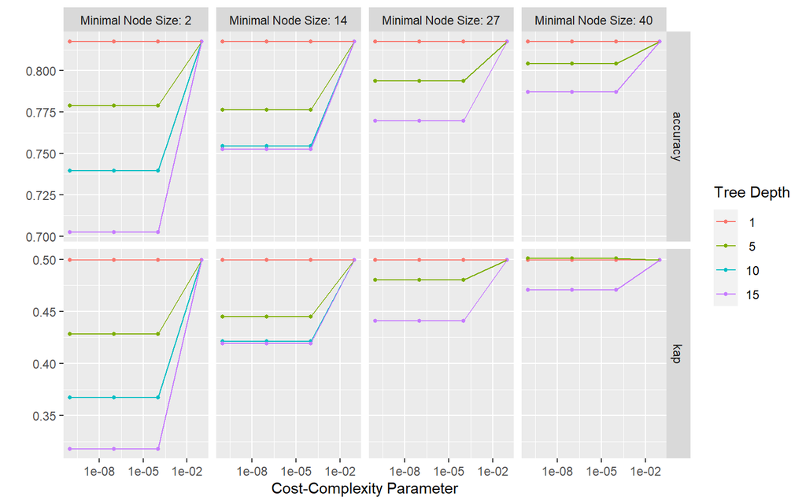

```r
# tree_rs %>% autoplot() + theme_light(base_family = "IBMPlexSans")
tree_rs %>% autoplot()
```

### Finalize decision

We can finalize our decision and create our decision tree based on the following specification:

```r
show_best(tree_rs, "kap")
```

```
## # A tibble: 5 x 9
##   cost_complexity tree_depth min_n .metric .estimator  mean     n std_err
##             <dbl>      <int> <int> <chr>   <chr>      <dbl> <int>   <dbl>
## 1    0.0000000001          5    40 kap     binary     0.501    10  0.0388
## 2    0.0000001             5    40 kap     binary     0.501    10  0.0388
## 3    0.0001                5    40 kap     binary     0.501    10  0.0388
## 4    0.0000000001          1     2 kap     binary     0.499    10  0.0485
## 5    0.0000001             1     2 kap     binary     0.499    10  0.0485
## # ... with 1 more variable: .config <chr>
```

```r
final_tree <- finalize_model(tree_engine, select_best(tree_rs, "kap"))

final_tree
```

```
## Decision Tree Model Specification (classification)
##
## Main Arguments:
##   cost_complexity = 1e-10
##   tree_depth = 5
##   min_n = 40
##
## Computational engine: rpart
```

A visual of our fitted model tree to the training dataset is shown below. The first value in the tree nodes indicate Y/N on whether there loan default would be predicted at that node, the second values shows the probability associated with `N` on the left and `Y` on the right. the third row in the node shows the percentage of the data contained in each node. The top most node depicts the most descriptive feature of our classification model, while following nodes depict secondary descriptive features. Due to the tree specifications (40 data points needed minimum at each node) only two main features are used to predict `LoanStatus` which are `Credit_History` and `IncomeLoanRatio`.

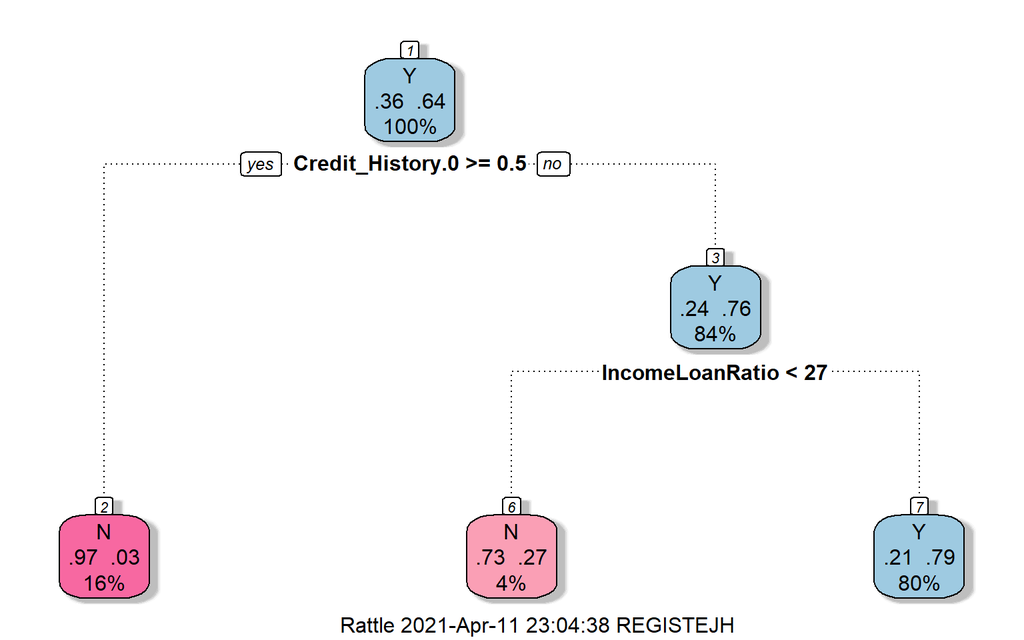

```r
final_wf <-
  workflow() %>%
  add_model(final_tree) %>%
  add_recipe(dt_recipe6)

wf_final_results <- final_wf %>%
  fit_resamples(
    resamples = datacv,
    metrics = metric_set(
      roc_auc, accuracy, sensitivity, specificity, kap),
    control = control_resamples(save_pred = TRUE))


All_metrics <- wf_res_function(wf_final_results, "wf_final")

dtmodel <- final_wf %>% fit(data = Datatrain)

rattle::fancyRpartPlot(dtmodel$fit$fit$fit,palettes="RdPu")
```